# CV-Ingeniera de Petróleo - PM Ciberseguridad Industrial

Andryus Mijares

2024-04-04

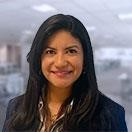

# Ingeniera Andryus Mijares

#### **Datos personales**

| **Nacionalidad** | **Edad** | **Ubicación** | **Célular** | **E-mail** |
| --- | --- | --- | --- | --- |
| Venezolana | 37 años | Villa Urquiza-CABA | 11 3232-3644 | ing.melinamijares@gmail.com |

#### **Experiencia:**

| **Año** | **Empresa** | **Cargo** |
| --- | --- | --- |
| **2022 - Actualmente** | KPMG - YPF | PM Consultora de Ciberseguridad Industrial |
| **2022** | Service IT | Account Manager de Ciberseguridad IT |
| **2021 - 2022** | Iting | Ingeniera de Preventa de Ciberseguridad IT |

#### **Estudios:**

- **2024**: Diplomatura de Extensión Universitaria en Gestión y Tecnologías para el Desarrollo Convencional y No Convencional de Hidrocarburos, UNPA-UACO.
- **2023**: Diplomatura Ciberseguridad en Sistemas Industriales(ICS/OT)__, UNSTA.
- **2019**: Postgrado: Gestión de Proyectos__,Universidad Tecnológica Nacional, UTN.
- **2015**: Postgrado: Maestría en Gestión de la Energía, Universidad Nacional de Lanús UNLa.
- **2015**: Postgrado: Especialización en Gerencia Integrada de Yacimientos de Hidrocarburos, Universidad Central de Venezuela UCV.
- **2013**: Ingeniera de Petróleo, Universidad Central de Venezuela UCV.

#### **Idioma:**

- Inglés: Intermedio profesional.

#### **Habilidades técnicas:**

- Conocimientos de PMI (gestión de proyectos).
- Conocimientos de redes de comunicaciones LAN, MAN y WAN.
- Conocimientos técnicos específicos en tecnologías de redes de control, SCADA (Supervisory Control And Data Acquisition), HMI, RTU, DCS (distributed control system ), PLC, etc.
- Conocimientos de arquitecturas y mejores prácticas de sistemas industriales.
- Experiencia en proyectos de seguridad de redes de automatización y control.
- Conocimientos de redes inalámbricas 802.15.4 SCADA.
- Conocimiento de normativas ISA99-IEC62443 y de la familia ISO 27000 / COBIT , ISO31000 e ISO22301.
- Conocimientos de seguridad en sistemas operativos Linux, Windows.
- Conocimientos básicos de ITIL y en general en operación de sistemas de gestión de incidentes.
- Experiencia en análisis de vulnerabilidades y auditoria en general para este tipo de sistemas industrial.
- Conocimiento y comprensión de normativas de Ciberseguridad industrial a nivel nacional e internacional.

#### **Habilidades blandas:**

- Autodidácta en constante aprendizaje.
- Excelente relaciones interpersonales.
- Resolutiva con mentalidad urgente y escasa.
- Carismática con buena comunicación efectiva.
- Trabajo en equipo, líder y enérgica.
- Analítica, perseverante y emprendedora.
- Adaptable a los cambios, optimista y resiliente.
- Confiable, responsable, honesta y empática.